# UFO Sightings

### CMSC320 Project

### By: Alisha Asnani

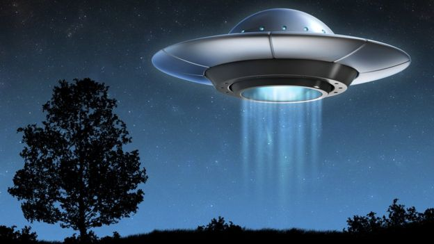

```python
from IPython.display import Image
Image("UFO_img.jpg")
```

## Introduction

For decades there has been a heated debate on whether aliens exist or not. The biggest evidence for aliens existing is the large amount of UFO sightings throughout the years. The purpose of this tutorial is to show how to collect and analyze UFO sighting data in order to see if there is a expaination for UFO sightings like people's belief in the extraterrestrial intensified by movies released at the time.

## Data Collection

In this tutorial, we will be using 2 datasets collected from Kaggle

```
 UFO sightings dataset: https://www.kaggle.com/NUFORC/ufo-sightings
 TMDB 5000 Movie dataset: https://www.kaggle.com/tmdb/tmdb-movie-metadata
```

The UFO sightings dataset is collected by the National UFO Reporting Center (NUFORC) which specilizes in recording UFO sightings from all over the world.

The TMDB 5000 Movie dataset is collected from The Movie Database (TMDb) which, since 2008, has had public users add and edit missing/incorrect data.

All you have to do is downloading both datasets from kaggle into the same folder as this notebook.

## Collecting and Cleaning the Data

```python
import numpy as np
import pandas as pd
import datetime
import folium
import matplotlib.pyplot as plt
import ast
```

### UFO data

This collects UFO sightings data. Make sure that you have downloaded and placed the data in the same folder as the notebook. Also, this code makes sure that, for all columns, the datatypes are strings.

```python
df = pd.read_csv('UFO.csv', dtype={
    'datetime': str, 'city': str, 'state': str, 'country':str, 'shape':str, 'duration (seconds)':str,
       'duration (hours/min)':str, 'comments':str, 'date posted':str, 'latitude':str,
       'longitude ':str })
```

This code below splits datetime string in order to fix time recording discrepancies like recording midnight as both 24:00 and 00:00 and converts date and time, into datetime objects.

```python
df['date'], time = df['datetime'].str.split().str
time = time.replace('24:00', '00:00')
```

```python
#string version of datetime for later
df['datetimestr'] = df['datetime']

#make all date columns datetime objects
df['datetime'] = pd.to_datetime(df['date'] + ' ' + time)
df['date'] = pd.to_datetime(df['date'])
df['date posted'] = pd.to_datetime(df['date posted'])
```

This code corrects some small data entering mistakes that I noticed like hanging letters and apostrophes and converts numeric data into float.

```python
#fixing errors (extra letters) in latitude data recording
df.set_value( 43782, 'latitude', 33.200088)
df['latitude'] = pd.to_numeric(df['latitude'])
df['longitude '] = pd.to_numeric(df['longitude '])
```

```python
#fixing errors (extra letters and `) in duration data recording
df['duration (seconds)'] = df['duration (seconds)'].replace('`','')
df.set_value( 58591, 'duration (seconds)', 0.5)
df.set_value( 27822, 'duration (seconds)', 2)
df.set_value( 35692, 'duration (seconds)', 8)
df['duration (seconds)'] = pd.to_numeric(df['duration (seconds)'])
df.head()
```

|  | datetime | city | state | country | shape | duration (seconds) | duration (hours/min) | comments | date posted | latitude | longitude | date | datetimestr |
| --- | --- | --- | --- | --- | --- | --- | --- | --- | --- | --- | --- | --- | --- |
| 0 | 1949-10-10 20:30:00 | san marcos | tx | us | cylinder | 2700.0 | 45 minutes | This event took place in early fall around 194... | 2004-04-27 | 29.883056 | -97.941111 | 1949-10-10 | 10/10/1949 20:30 |
| 1 | 1949-10-10 21:00:00 | lackland afb | tx | NaN | light | 7200.0 | 1-2 hrs | 1949 Lackland AFB&#44 TX. Lights racing acros... | 2005-12-16 | 29.384210 | -98.581082 | 1949-10-10 | 10/10/1949 21:00 |
| 2 | 1955-10-10 17:00:00 | chester (uk/england) | NaN | gb | circle | 20.0 | 20 seconds | Green/Orange circular disc over Chester&#44 En... | 2008-01-21 | 53.200000 | -2.916667 | 1955-10-10 | 10/10/1955 17:00 |
| 3 | 1956-10-10 21:00:00 | edna | tx | us | circle | 20.0 | 1/2 hour | My older brother and twin sister were leaving ... | 2004-01-17 | 28.978333 | -96.645833 | 1956-10-10 | 10/10/1956 21:00 |
| 4 | 1960-10-10 20:00:00 | kaneohe | hi | us | light | 900.0 | 15 minutes | AS a Marine 1st Lt. flying an FJ4B fighter/att... | 2004-01-22 | 21.418056 | -157.803611 | 1960-10-10 | 10/10/1960 20:00 |

### Movie data

The code below collects the movie data and only keeps the movies that have Science Fiction or Fantasy tags since those movies are the most likely to have aliens and might intensify the viewers' beliefs in the extraterrestrial.

```python
# to figure out if the movie has a Science Fiction or Fantasy tag
def search(gen):
    for g in gen:
        if g['name'] == 'Science Fiction':
            return 'Science Fiction'
        if g['name'] == 'Fantasy':
            return 'Fantasy'
    return np.nan
```

```python
# collects all the movie data and searches for Syfy and Fantasy tags
# only keeping those movies
df_movies = pd.read_csv('movies.csv')


df_movies['genres'] = df_movies['genres'].apply(lambda x: ast.literal_eval(x))
df_movies['genres'] = df_movies['genres'].apply(lambda x: search(x))

df_movies = df_movies.dropna()
df_movies['release_date'] = pd.to_datetime(df_movies['release_date'])
df_movies.head()
```

|  | budget | genres | homepage | id | keywords | original_language | original_title | overview | popularity | production_companies | production_countries | release_date | revenue | runtime | spoken_languages | status | tagline | title | vote_average | vote_count |
| --- | --- | --- | --- | --- | --- | --- | --- | --- | --- | --- | --- | --- | --- | --- | --- | --- | --- | --- | --- | --- |
| 0 | 237000000 | Fantasy | http://www.avatarmovie.com/ | 19995 | [{"id": 1463, "name": "culture clash"}, {"id":... | en | Avatar | In the 22nd century, a paraplegic Marine is di... | 150.437577 | [{"name": "Ingenious Film Partners", "id": 289... | [{"iso_3166_1": "US", "name": "United States o... | 2009-12-10 | 2787965087 | 162.0 | [{"iso_639_1": "en", "name": "English"}, {"iso... | Released | Enter the World of Pandora. | Avatar | 7.2 | 11800 |
| 1 | 300000000 | Fantasy | http://disney.go.com/disneypictures/pirates/ | 285 | [{"id": 270, "name": "ocean"}, {"id": 726, "na... | en | Pirates of the Caribbean: At World's End | Captain Barbossa, long believed to be dead, ha... | 139.082615 | [{"name": "Walt Disney Pictures", "id": 2}, {"... | [{"iso_3166_1": "US", "name": "United States o... | 2007-05-19 | 961000000 | 169.0 | [{"iso_639_1": "en", "name": "English"}] | Released | At the end of the world, the adventure begins. | Pirates of the Caribbean: At World's End | 6.9 | 4500 |
| 4 | 260000000 | Science Fiction | http://movies.disney.com/john-carter | 49529 | [{"id": 818, "name": "based on novel"}, {"id":... | en | John Carter | John Carter is a war-weary, former military ca... | 43.926995 | [{"name": "Walt Disney Pictures", "id": 2}] | [{"iso_3166_1": "US", "name": "United States o... | 2012-03-07 | 284139100 | 132.0 | [{"iso_639_1": "en", "name": "English"}] | Released | Lost in our world, found in another. | John Carter | 6.1 | 2124 |
| 5 | 258000000 | Fantasy | http://www.sonypictures.com/movies/spider-man3/ | 559 | [{"id": 851, "name": "dual identity"}, {"id": ... | en | Spider-Man 3 | The seemingly invincible Spider-Man goes up ag... | 115.699814 | [{"name": "Columbia Pictures", "id": 5}, {"nam... | [{"iso_3166_1": "US", "name": "United States o... | 2007-05-01 | 890871626 | 139.0 | [{"iso_639_1": "en", "name": "English"}, {"iso... | Released | The battle within. | Spider-Man 3 | 5.9 | 3576 |
| 7 | 280000000 | Science Fiction | http://marvel.com/movies/movie/193/avengers_ag... | 99861 | [{"id": 8828, "name": "marvel comic"}, {"id": ... | en | Avengers: Age of Ultron | When Tony Stark tries to jumpstart a dormant p... | 134.279229 | [{"name": "Marvel Studios", "id": 420}, {"name... | [{"iso_3166_1": "US", "name": "United States o... | 2015-04-22 | 1405403694 | 141.0 | [{"iso_639_1": "en", "name": "English"}] | Released | A New Age Has Come. | Avengers: Age of Ultron | 7.3 | 6767 |

# Exploratory Analysis

## Looking at the UFO data

In this analysis part, we will look at different features of the UFO Sightings data and see if the features show any patterns.

## Where are the UFOs sightings?

### location

Using the library folium, we can map the locations of all the UFO sightings and look for any possible insights like if there are any clusters and outliers.

```python
df['popup'] = ("location: "+df['city']+ '\n' +
                "date: "+df['datetimestr']+ "\n" +
                "duration: "+df['duration (hours/min)']+ "\n" +
                "shape: "+df['shape']+ "\n" +
                "description: "+df['comments'])
```

```python
map_UFO = folium.Map(location=[39.29, -76.61], zoom_start=3)
```

```python
import folium.plugins
marker_cluster = folium.plugins.MarkerCluster().add_to(map_UFO)
```

```python
#only did the first 1500 because that is all my computer could take
#if you have a better computer, go for all of them!

for each in df[0:1500].to_records():
    folium.Marker(
        location = [each['latitude'],each['longitude ']],
        popup= str(each['popup'])
        ).add_to(marker_cluster)
map_UFO
```

[interactive chart not shown]

Most of the sightings tend to happen in developed countries around the world. There are very few markers in third world countries. It could be that the people in those countries don't know about the National UFO Reporting Center (NUFORC) or have no way to get in contact with the center. Also, this could be because of movies not being released in third-world counties.

## How long did the UFO stay?

### Duration

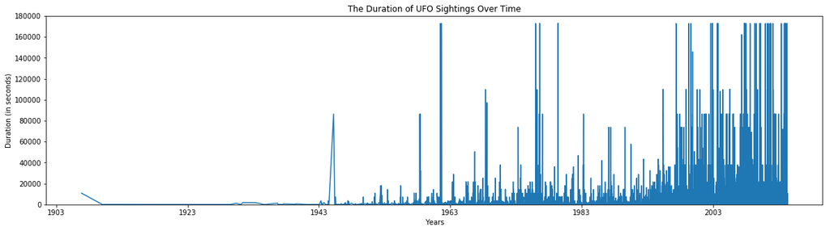

```python
dur_plot = df.sort_values(by='date')
dur_plot = dur_plot[dur_plot['duration (seconds)'] < 180000]
plt.figure(1, figsize=(20,5))
plt.ylim((0,180000))
plt.title('The Duration of UFO Sightings Over Time')
plt.xlabel('Years')
plt.ylabel('Duration (in seconds)')
plt.plot(dur_plot['date'], dur_plot['duration (seconds)'])

plt.show()
```

## What did the UFOs look like?

There are two descriptions of the UFOs in the dataset. One is shape, where is reporter is told to describe the shape of the UFO as best they can. The other is comments, where is a more general description of the UFO.

#### Shape

The following code combines similar reported shapes into one catagory so that the frequency of each shape is accurate.

```python
df['shape'] = df['shape'].replace(np.nan, 'unknown')
df['shape'] = df['shape'].replace('other', 'unknown')
df['shape'] = df['shape'].replace('changed', 'changing')
df['shape'] = df['shape'].replace('round', 'circle')
df['shape'].unique()
```

```
array(['cylinder', 'light', 'circle', 'sphere', 'disk', 'fireball',
       'unknown', 'oval', 'cigar', 'rectangle', 'chevron', 'triangle',
       'formation', 'delta', 'changing', 'egg', 'diamond', 'flash',
       'teardrop', 'cone', 'cross', 'pyramid', 'crescent', 'flare',
       'hexagon', 'dome'], dtype=object)
```

Using collections.Counter we can counter then number of times the same shape is reported and then plot that in a bar plot.

Looking at the bar chart and the most commmon list, most people that reported seeing the UFO said that it was a bright light or could not make out the shape.

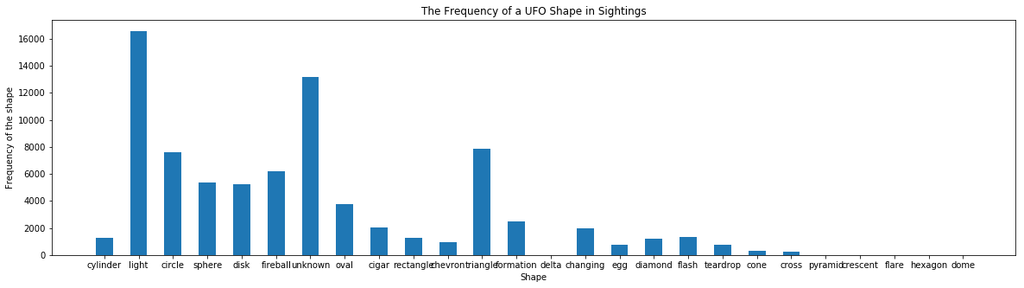

```python
from collections import Counter
x = Counter(df['shape'])
labels, values = zip(*x.items())

indexes = np.arange(len(labels))
width = .5
plt.figure(1, figsize=(20,5))
plt.bar(indexes, values, width, align='center')
plt.xticks(indexes, labels)
plt.title('The Frequency of a UFO Shape in Sightings')
plt.xlabel('Shape')
plt.ylabel('Frequency of the shape')
plt.show()
```

```python
print(x.most_common())
```

```
[('light', 16565), ('unknown', 13165), ('triangle', 7865), ('circle', 7610), ('fireball', 6208), ('sphere', 5387), ('disk', 5213), ('oval', 3733), ('formation', 2457), ('cigar', 2057), ('changing', 1963), ('flash', 1328), ('rectangle', 1297), ('cylinder', 1283), ('diamond', 1178), ('chevron', 952), …
```

#### Comments

##### WordCloud

With the comments data, we can create a word cloud. In a word cloud, the more frequently a word was used in the comments, the larger the word shows up in the cloud. This is a easy visual way to see which were the most common words used in really large strings like in the comments.

```python
from wordcloud import WordCloud
import re

x = df["comments"].replace(re.compile('\&\#\d\d'), '')
text = x.dropna().str.cat(sep='')
text = text.replace('NUFORC Note', '')
text = text.replace('&quot;', '')
wordcloud = WordCloud().generate(text)
```

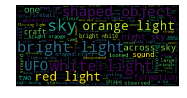

```python
wordcloud = WordCloud(max_font_size=40).generate(text)
plt.figure()
plt.imshow(wordcloud, interpolation="bilinear")
plt.axis("off")
plt.show()
```

Looking at the word cloud, the largest words are pretty much the same as the shapes, bright lights moving around in the sky.

## When Did the Sightings Happen?

By ploting the frequency of sightings per year, we can see that, in recent years, there has been a sharp increase in the number of UFO sightings, upto almost 8000 in a year!

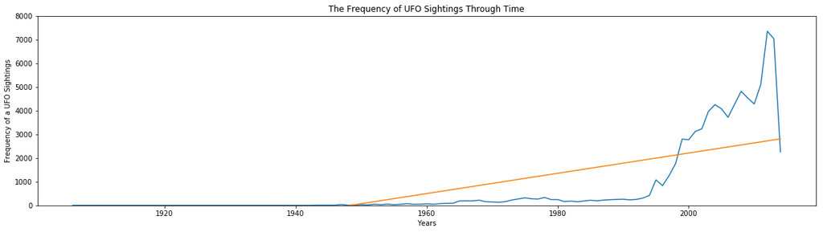

```
42.7958743443
```

```python
from collections import Counter
df['year'] = df['date'].apply(lambda x: x.year)

x = Counter(df['year'])
labels, values = zip(*x.items())

occur = pd.DataFrame(data = list(labels), columns=['year'])
occur['freq'] = list(values)

occur = occur.sort_values(by='year').dropna()

plt.figure(1, figsize=(20,5))
plt.plot(occur['year'], occur['freq'])
m, b = np.polyfit(occur['year'], occur['freq'], 1)
plt.ylim((0,8000))
plt.plot(occur['year'], m*occur['year'] + b, '-')
plt.title('The Frequency of UFO Sightings Through Time')
plt.ylabel('Frequency of a UFO Sightings')
plt.xlabel('Years')
plt.show()
print(m)

sight_freq = occur
```

```python
df['time to report'] = df['date posted'] - df['datetime']
print (df['time to report'].max())
print (df['time to report'].median())
```

```
35106 days 00:00:00
26 days 01:00:00
```

For many of these sightings, it can take a long time, even years before the sighting is reported. For this data, the maximum time that it took someone to report a UFO slighting was 35106 days or 96 years! The median reporting time was about 26 days. I did not use the mean, because it was heavily skewed by extreme numbers like the 96 years mentioned before. However, 26 days is still a large number and the large delay in reporting can cast doubt on the accuracy in the reports and the validity of the sighting.

#### Movie releases through time

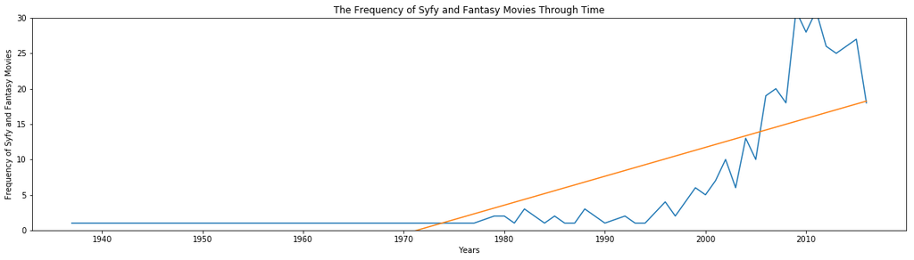

```python
df_movies['year'] = df_movies['release_date'].apply(lambda x: x.year)
x = Counter(df_movies['year'])
labels, values = zip(*x.items())

occur = pd.DataFrame(data = list(labels), columns=['year'])
occur['movies'] = list(values)

occur = occur.sort_values(by='year')

plt.figure(1, figsize=(20,5))
plt.plot(occur['year'], occur['movies'])
m, b = np.polyfit(occur['year'], occur['movies'], 1)
plt.ylim((0,30))
plt.plot(occur['year'], m*occur['year'] + b, '-')
plt.title('The Frequency of Syfy and Fantasy Movies Through Time')
plt.ylabel('Frequency of Syfy and Fantasy Movies')
plt.xlabel('Years')
plt.show()
```

The chart above shows the increase in Syfy and Fantasy films through time. As you can see, the trend is very similar to the UFO sightings.

# Machine Learning and Hypothesis Testing

## Could it be the movies?

After looking at all the exploratory data, I feel that there could be a correlation between when science fiction and fantasy movies are released and the number of UFO sightings.

The following code is analysing science fiction and fantasy movie releasings. It is possible that with the increase in these movies, people would be more likely to think they have seen a UFO. My null hypothesis is that there is little to no correlation between the number of UFO sightings and the number of science fiction and fantasy movies released. In order to reject the null hypothesis, the p-value of the regression should be less than .05 as that would suggest a strong relationship.

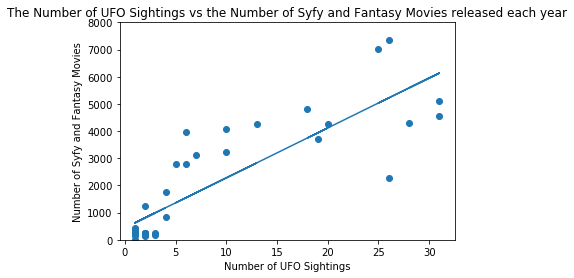

```python
df_combined = pd.merge(occur, sight_freq, on=['year'], how='inner')
plt.scatter(df_combined['movies'], df_combined['freq'])
m, b = np.polyfit(df_combined['movies'], df_combined['freq'], 1)
plt.ylim((0,8000))
plt.plot(df_combined['movies'], m*df_combined['movies'] + b, '-')
plt.title('The Number of UFO Sightings vs the Number of Syfy and Fantasy Movies released each year')
plt.ylabel('Number of Syfy and Fantasy Movies')
plt.xlabel('Number of UFO Sightings')
plt.show()
```

We can also plot the number of sights by the number of movies released to see the corrolation between the two variables. It seems quite high.

### Linear Regression

```python
from sklearn.model_selection import train_test_split

X_train, X_test, y_train, y_test = np.asarray(train_test_split(df_combined['freq'], df_combined['movies'], test_size=0.4))
```

```python
from sklearn.linear_model import LinearRegression

reg = LinearRegression()
reg.fit(X_train.values.reshape(-1,1), y_train.values.reshape(-1,1))
print('Score: ', reg.score(X_test.values.reshape(-1,1), y_test.values.reshape(-1,1)))
```

```
Score:  0.685123549954
```

R-squared values show how well the prediction or the line fits the data. High r-squared values, like the one we got, suggest high correlation.

```python
import statsmodels.api as sm
from statsmodels.formula.api import ols
est = ols('freq ~ movies', data=df_combined) # old regression on lifeExp and year only
est2 = est.fit()
print(est2.summary())
```

```
                            OLS Regression Results
==============================================================================
Dep. Variable:                   freq   R-squared:                       0.723
Model:                            OLS   Adj. R-squared:                  0.716
Method:                 Least Squares   F-statistic:                     94.16
Date:                Sat, 16 Dec 2017   Prob (F-statistic):           1.38e-11
Time:                        16:38:47   Log-Likelihood:                -320.61
No. Observations:                  38   AIC:                             645.2
Df Residuals:                      36   BIC:                             648.5
Df Model:                           1
Covariance Type:            nonrobust
==============================================================================
                 coef    std err          t      P>|t|      [0.025      0.975]
------------------------------------------------------------------------------
Intercept    444.0945    244.998      1.813      0.078     -52.784     940.973
movies       183.5856     18.920      9.703      0.000     145.215     221.957
==============================================================================
Omnibus:                        1.082   Durbin-Watson:                   1.102
Prob(Omnibus):                  0.582   Jarque-Bera (JB):                0.501
Skew:                           0.268   Prob(JB):                        0.778
Kurtosis:                       3.170   Cond. No.                         17.1
==============================================================================

Warnings:
[1] Standard Errors assume that the covariance matrix of the errors is correctly specified.
```

```python
est2.pvalues
```

```
Intercept    7.823228e-02
movies       1.380155e-11
dtype: float64
```

## Conclusion and Insight

In this tutorial, I covered some basic ways to interact, edit, and analyze UFO Sightings data from National UFO Reporting Center (NUFORC) and Movie data from The Movie Database (TMDb). The libraries and tools I used are Anaconda, Jupyter Notebook, Matplotlib, ast, Folium, Numpy, Pandas, Regular Expressions Library, WordCloud, pandas, Sklearn, IPython. I hope you have enjoyed this tutorial on UFO Sightings.